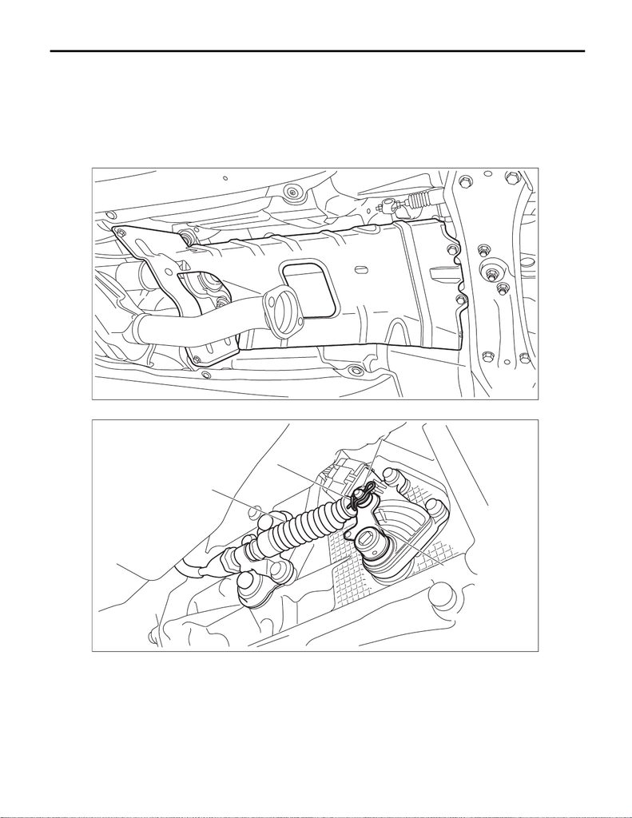

CS-42

Select Cable

CONTROL SYSTEMS

4. Select Cable

A: REMOVAL

1) Shift the select lever to “N” range.

2) Disconnect the ground terminal from battery sensor. <Ref. to NT-5, BATTERY, NOTE, Note.>

3) Lift up the vehicle.

4) Remove the center exhaust pipe (rear). <Ref. to EX(w/o STI)-35, REMOVAL, Center Exhaust Pipe.>

5) Remove the center exhaust cover.

6) Remove the snap pin and washer from the shifter arm.

(A) Shifter arm (C) Select cable (D) Washer

(B) Snap pin

AT-07743

CS-01373

(C)

(B)

(D)

(A)

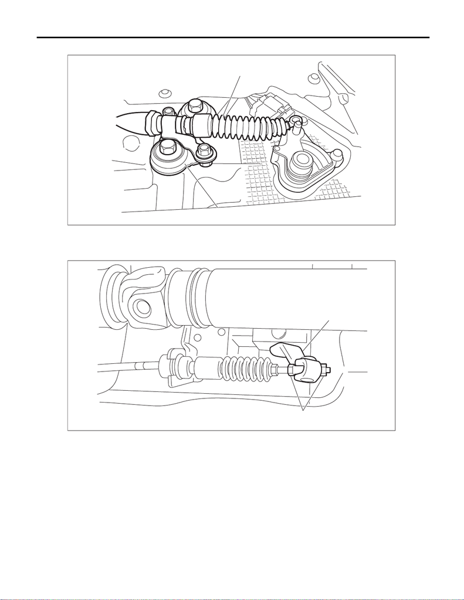

CS-43

Select Cable

CONTROL SYSTEMS

7) Remove the plate assembly.

8) Disconnect the cable from arm COMPL.

(A) Select cable (B) Plate ASSY

(A) Adjusting nut (B) Arm COMPL

CS-01375

(A)

(B)

CS-01655

(B)

(A)

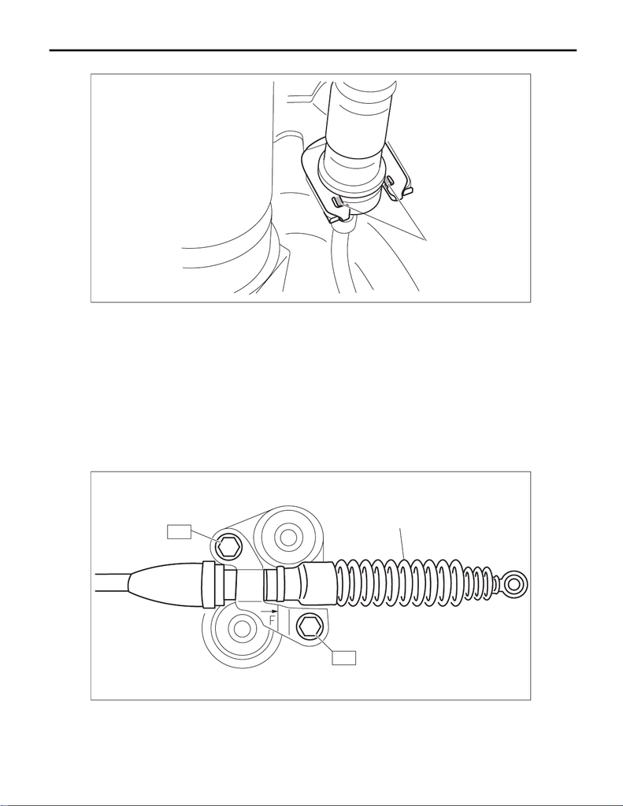

CS-44

Select Cable

CONTROL SYSTEMS

9) Raise the claw of clamp and remove the cable.

10) Remove the select cable from plate assembly.

B: INSTALLATION

1) Position the select cable as shown in the figure, and install it to the plate assembly.

CAUTION:

• If the cable is installed in the wrong direction, loosen the bracket bolts, and then reinstall the cable

in the correct direction.

• Do not forcibly turn the cable (wire side) to align the direction correctly.

Tightening torque:

T: 18 N·m (1.8 kgf-m, 13.3 ft-lb)

(A) Claw

(A) Select cable

CS-01536

(A)

(A)

T

T

CS-01640

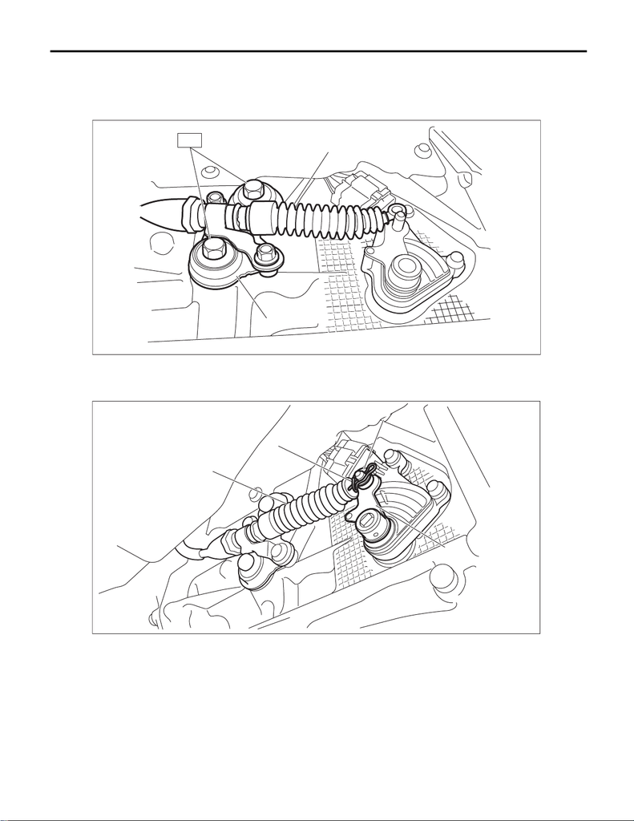

CS-45

Select Cable

CONTROL SYSTEMS

2) Install the select cable to the shifter arm.

3) Install the plate assembly.

Tightening torque:

T: 25 N·m (2.5 kgf-m, 18.4 ft-lb)

4) Install the washer and snap pin to the shifter arm.

(A) Select cable (B) Plate ASSY

(A) Shifter arm (C) Select cable (D) Washer

(B) Snap pin

CS-01540

(A)

(B)

T

CS-01373

(C)

(B)

(D)

(A)

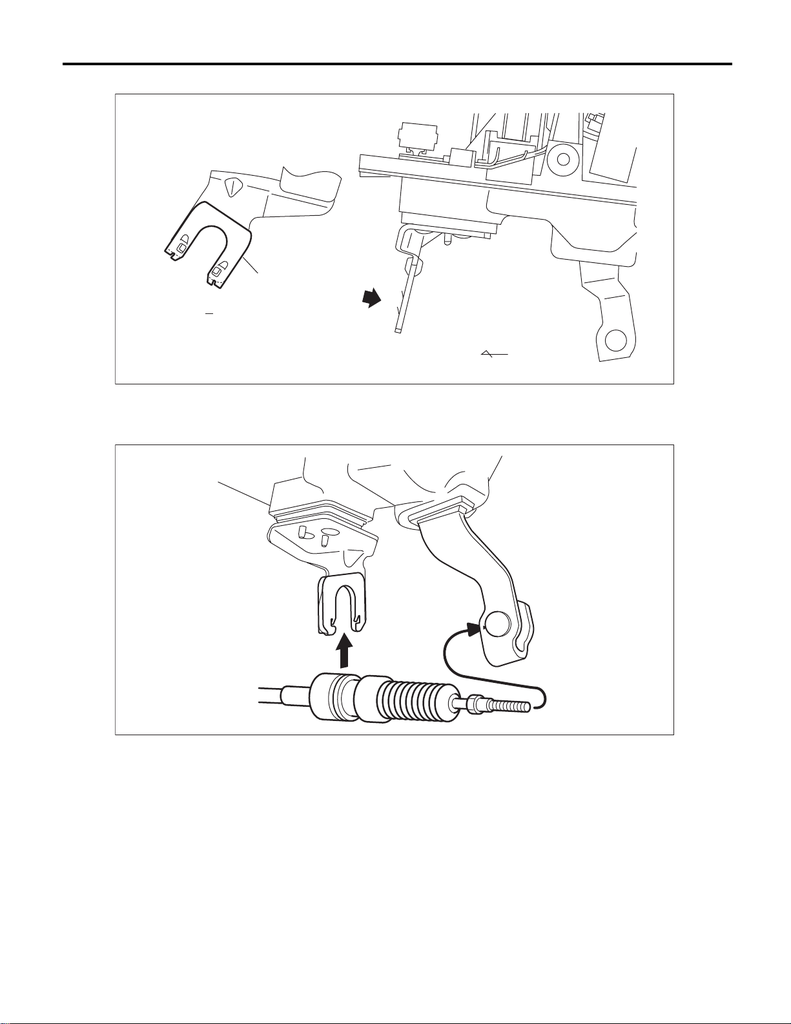

CS-46

Select Cable

CONTROL SYSTEMS

5) Install new clamp paying attention to the installing direction.

6) Insert the tip of inner cable into connector hole of select lever, and fix the cable to bracket.

7) Shift the select lever to the “N” range, and then adjust the select cable position. <Ref. to CS-47, ADJUST-

MENT, Select Cable.>

8) Install the center exhaust cover.

Tightening torque:

18 N·m (1.8 kgf-m, 13.3 ft-lb)

9) Install the center exhaust pipe (rear). <Ref. to EX(w/o STI)-41, INSTALLATION, Center Exhaust Pipe.>

10) Lower the vehicle.

11) Connect the ground terminal to battery sensor. <Ref. to NT-5, BATTERY, NOTE, Note.>

(A) Clamp (B) Forward

CS-01134

C

C

(A)

(B)

CS-01613

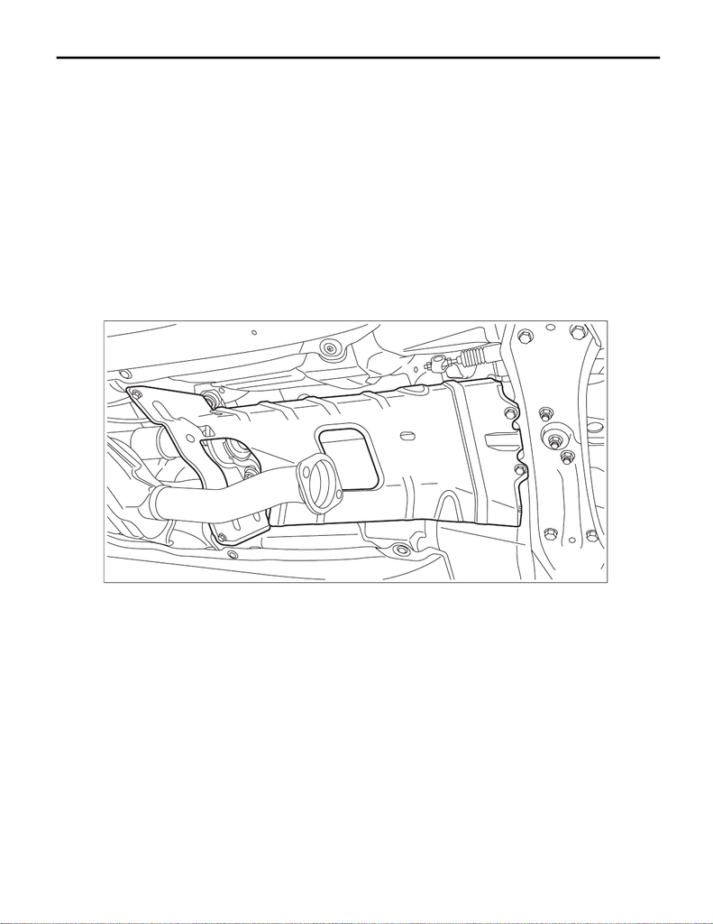

CS-47

Select Cable

CONTROL SYSTEMS

C: INSPECTION

Check the removed cable and replace or adjust if damaged, rusty or malfunctioning.

1) Check the cable for smooth operation.

2) Check the inner cable for damage and rust.

3) Check the outer cable for damage, bends and cracks.

4) Check the boot for damage, cracks and deterioration.

5) Move the select lever from “P” to “D” range. Check the existence of feel to contact the detents in each

range. If the detents cannot be felt or the position pointer is improperly aligned, adjust the cable.

6) Check if the starter motor rotates when the select lever is set to “P” range.

7) Check the back-up light illumination when the select lever is in “R” range.

8) Check the parking lock operation when the select lever is in “P” range.

D: ADJUSTMENT

1) Shift the select lever to “N” range.

2) Lift up the vehicle.

3) Remove the center exhaust pipe (rear). <Ref. to EX(w/o STI)-35, REMOVAL, Center Exhaust Pipe.>

4) Remove the center exhaust cover.

AT-07743

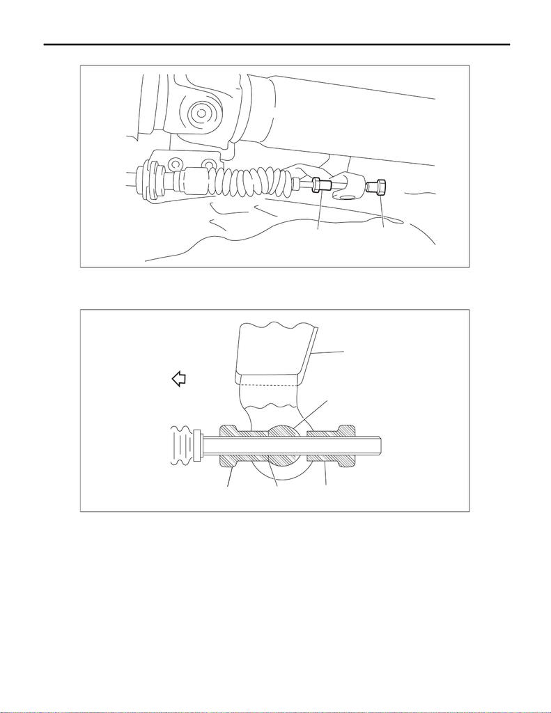

CS-48

Select Cable

CONTROL SYSTEMS

5) Loosen the adjusting nuts on both sides.

6) Turn adjusting nut B until it lightly touches the connector.

(A) Adjusting nut A (B) Adjusting nut B

(A) Forward side (C) Connector (E) Contact point

(B) Select lever (D) Adjusting nut B (F) Adjusting nut A

CS-01136

( A )

( B )

CS-01245

(A)

(B)

(C)

(D)

(E)

(F)

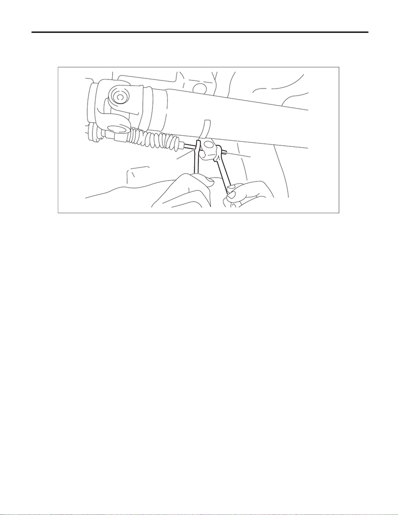

CS-49

Select Cable

CONTROL SYSTEMS

7) Set a spanner wrench to adjusting nut B so that it does not rotate, and then tighten the adjusting nut A.

Tightening torque:

7.5 N·m (0.76 kgf-m, 5.5 ft-lb)

8) After the completion of adjustment, confirm that the select lever operates normally at all ranges.

9) Installing procedure hereafter is in the reverse order of removal.

(A) Adjusting nut A (B) Adjusting nut B

CS-01138

( A )

( B )